# Assignment 4 - Data Visualization

Martijn Straatsburg - S3726134

May 19, 2025

## Visualization

### Packages & Data

This is a historical dataset on the modern Olympic Games, including all the Games from Athens 1896 to Rio 2016. The data was retrieved from [here](https://www.kaggle.com/heesoo37/120-years-of-olympic-history-athletes-and-results).

```r
library(ggplot2)
# To suppress the conflicts of the packages with base R functions
suppressPackageStartupMessages(library(tidyverse))
suppressPackageStartupMessages(library(dplyr))
data  <- read.csv("https://stulp.gmw.rug.nl/dataviz/athlete_events.csv",
                 header = TRUE)
```

### Code to create visualization

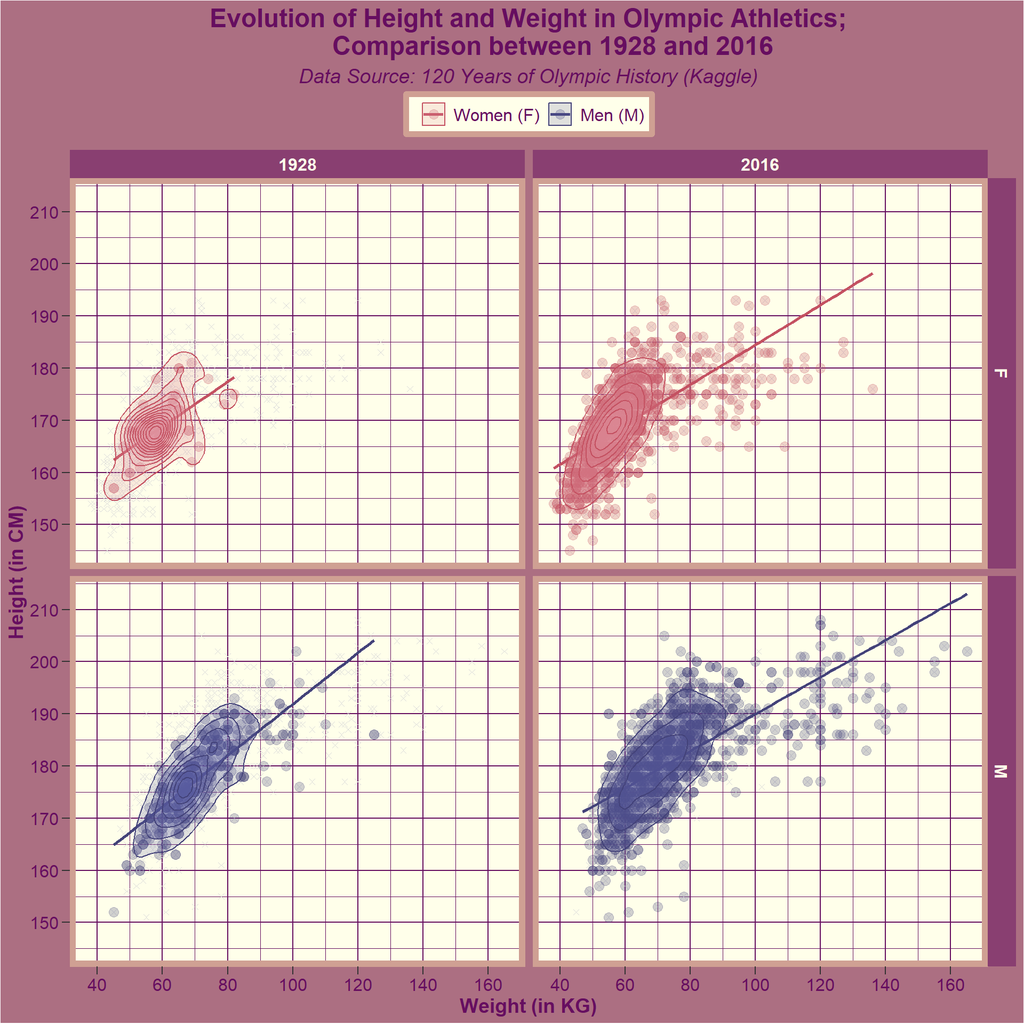

```r
# Load Athletics data from 1928 & 2016 and filter out NA's
athl_data <- data %>%
  filter(Sport == "Athletics",
         Year %in% c(1928, 2016)) %>%
  filter(!is.na(Height), !is.na(Weight))

# Create Olympic theme
olympic_theme <- theme(
  panel.background = element_rect(fill = "#ffffea"),
  panel.border = element_rect(linewidth = 4, colour = "#cfa093", fill = NA),
  plot.background = element_rect(fill = "#ac6f82"),
  panel.grid.major = element_line(colour = "#660e60"),
  panel.grid.minor = element_line(colour = "#660e60"),
  axis.title = element_text(face = "bold", colour = "#660e60", size = 14),
  axis.text = element_text(colour = "#660e60", size = 12),
  axis.ticks.length = unit(.2, "cm"),
  plot.title = element_text(face = "bold", size = 18,
                            colour = "#660e60", hjust = 0.5),
  plot.subtitle = element_text(face = "italic", size = 14,
                               colour = "#660e60", hjust = 0.5),
  strip.background = element_rect(fill = "#893f71"),
  strip.text = element_text(face = "bold", colour = "#ffffea", size = 12),
  legend.position = "top",
  legend.background = element_rect(fill = "#ffffea", colour = "#cfa093",
                                   linewidth = 2),
  legend.title = element_text(face = "bold", colour = "#660e60"),
  legend.text = element_text(size = 12, colour = "#660e60")
)

# Facet Scatter & Density plot with raw data and regression line
ggplot(athl_data, aes(x = Weight, y = Height, color = Sex)) +
  geom_point(data = transform(athl_data, Year = NULL),
             colour = "grey85", shape = 4) +
  geom_point(alpha = 0.25, size = 3, shape = 19) +
  geom_smooth(formula = "y ~ x", method = "lm", se = FALSE, aes(color = Sex)) +
  stat_density_2d(alpha = 0.2, geom = "polygon", aes(fill = Sex)) +
  scale_color_manual(name = "",
                     values = c("M" = "#434279", "F" = "#c45161"),
                     labels = c("M" = "Men (M)", "F" = "Women (F)")) +
  scale_fill_manual(name = "",
                    values = c("M" = "#5e62a9", "F" = "#e094a0"),
                    labels = c("M" = "Men (M)", "F" = "Women (F)")) +
  facet_grid(Sex ~ Year) +
  scale_y_continuous(breaks = seq(140, 220, by = 10),
                     labels = scales::comma) +
  scale_x_continuous(breaks = seq(40, 180, by = 20)) +
  labs(title = "Evolution of Height and Weight in Olympic Athletics;
       Comparison between 1928 and 2016",
       subtitle = "Data Source: 120 Years of Olympic History (Kaggle)",
       x = "Weight (in KG)", y = "Height (in CM)", colour = "Sex"
  ) +
  olympic_theme
```

## Description of visualization

The plot shows the evolution of the height and weight of male and female Olympic Athletics sporters and compares them between 1928 and 2016. It is a 4-way facet grid each layered with two scatterplots, a regression line and a density plot. One scatter plot is for that years’ data points (little bit see-through circles) and the other is for the full amount of data points of both years (light grey ’x’s).

Shortcomings might be that it solely focuses on 1928 and 2016 and doesn’t really show the evolution over all the years inbetween. Lastly, I’m just focusing on athletics and leaving out all the other sports. These require completely different body types and it would be interesting to see their history.

*243 words*

## References

- [Suppress Tidyverse Library Messages](https://stackoverflow.com/questions/48587115/turn-off-verbose-messages-when-loading-tidyverse-using-library-function)
- [Theme Colour Palette](https://colorkit.co/palette/660e60-893f71-ac6f82-cfa093-f3d0a4/)
- [Men & Women Colour Palette (only outer colours)](https://colorkit.co/palette/c45161-e094a0-f2b6c0-f2dde1-cbc7d8-8db7d2-5e62a9-434279/)
- [Scatter & Density plot Examples](https://r-graph-gallery.com/2d-density-plot-with-ggplot2.html)